# Unsupervised Learning

Ajeng Prastiwi

November 19, 2019

## Glimpse our Data

we will use `USArrests` datasets from R. Take a quick look at the datases, which comprise of arrests per 100.000 residents related to one of three crimes in each of the 50 US states in 1973

```r
data("USArrests")
head(USArrests)
```

|  | Murder | Assault | UrbanPop | Rape |
| --- | --- | --- | --- | --- |
| Alabama | 13.2 | 236 | 58 | 21.2 |
| Alaska | 10.0 | 263 | 48 | 44.5 |
| Arizona | 8.1 | 294 | 80 | 31.0 |
| Arkansas | 8.8 | 190 | 50 | 19.5 |
| California | 9.0 | 276 | 91 | 40.6 |
| Colorado | 7.9 | 204 | 78 | 38.7 |

Murder: murder arrests per 100,000 Assault: assault arrests per 100,000 UrbanPop: percent of population in urban areas Rape: rape arrests per 100,000

## Explore the data

```
##     Murder    Assault   UrbanPop       Rape
##   18.97047 6945.16571  209.51878   87.72916
```

## PCA in R

We use the `prcomp()` function, and we can add parameter `scale = TRUE` if we want the data to be scaled.

```
## Standard deviations (1, .., p=4):
## [1] 1.5748783 0.9948694 0.5971291 0.4164494
##
## Rotation (n x k) = (4 x 4):
##                 PC1        PC2        PC3         PC4
## Murder   -0.5358995  0.4181809 -0.3412327  0.64922780
## Assault  -0.5831836  0.1879856 -0.2681484 -0.74340748
## UrbanPop -0.2781909 -0.8728062 -0.3780158  0.13387773
## Rape     -0.5434321 -0.1673186  0.8177779  0.08902432
```

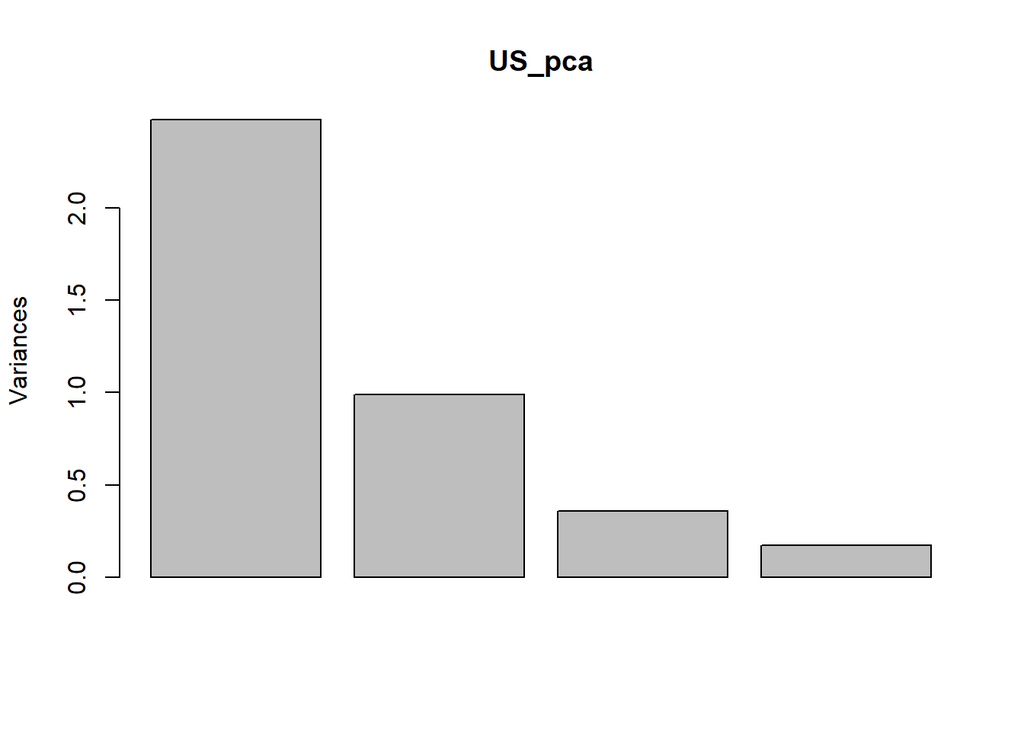

The `summary()` function tells us how much variation each of the principal components have captured in decreasing order

```
## Importance of components:
##                           PC1    PC2     PC3     PC4
## Standard deviation     1.5749 0.9949 0.59713 0.41645
## Proportion of Variance 0.6201 0.2474 0.08914 0.04336
## Cumulative Proportion  0.6201 0.8675 0.95664 1.00000
```

## Visualizing PCA

We can see the projection of our data on the first two principal component (PC1 and PC2) with `biplot` function.

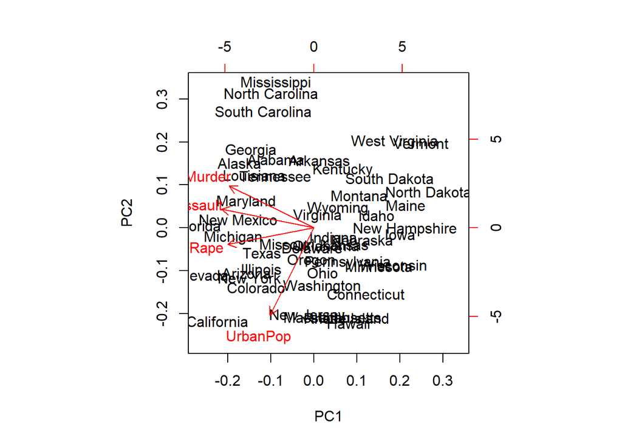

```r
biplot(US_pca)
```

## Dive Deeper

1. What does `eigenvalue` mean in PCA?
1. Eigen value explain the correlation between PC and original variable
2. Eigen value explain the coefficient for each Principal Component
3. Eigen value explain the variance for each Principal Component
2. Which of the following is `not true` about PCA?
1. PCA can visualizing high dimensional data
2. PCA will produce high correlation between each of the principal components
3. PCA tries to summarize the covariance betweens variables of our data